# 買賣家出價實驗結果之影響因素分析

此資料來源為台大經濟系助理教授陳儀 2019 所該開設的「實驗經濟學」之課堂實驗。實驗共有 50 回合，24 名參與者，參與者隨機分成三組，其中每組有 4 位賣家及 4 位買家。賣家在每回合開始時可以看到物品的真實價值(1~40 隨機給定)，並決定其出價；買家則決定其每回合的最高願付價格。

當買家最高願付價格<賣家出價時，該回合不成交，雙方報酬皆為 0。相反的，買家最高願付價格>賣家出價時，該回合成交。每回合結束時，雙方皆會知道此回合成交與否與彼此報酬。

- 成交時賣家報酬：賣家出價—1⁄2物品價值
- 成交時買家報酬：物品價值—賣家出價

```r
# 讀取並整理資料
library(ggplot2)
library(dplyr)
library(tidyr)

data <- read.csv("class_data.csv", stringsAsFactors = FALSE)

buyer_id <- unique(filter(data, type == 1)$subject)
seller_id <- unique(filter(data, type == 2)$subject)

data$subject <- as.character(data$subject)

buyer_data <- data %>%
  filter(data$subject %in% buyer_id)
seller_data <- data %>%
  filter(data$subject %in% seller_id)
```

### 問題 1：買家的願付價格(share)受到什麼因素影響?

#### 假設一：前回合的收入影響

統計上不顯著 (p-value: 0.1098)

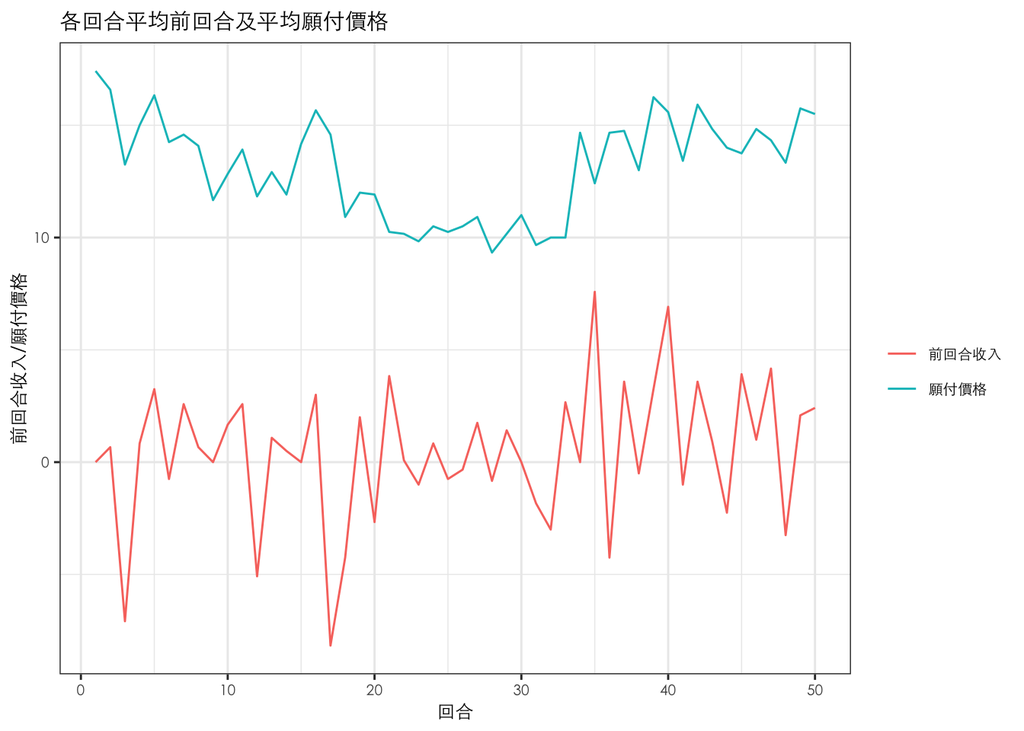

```
#>
#> Call:
#> lm(formula = mean_share ~ mean_previous_profit, data = buyer_pre_share_su)
#>
#> Residuals:
#>     Min      1Q  Median      3Q     Max
#> -3.5669 -1.9932  0.5002  1.6320  4.3799
#>
#> Coefficients:
#>                      Estimate Std. Error t value Pr(>|t|)
#> (Intercept)           13.0368     0.3099  42.070   <2e-16 ***
#> mean_previous_profit   0.1638     0.1006   1.629     0.11
#> ---
#> Signif. codes:  0 '***' 0.001 '**' 0.01 '*' 0.05 '.' 0.1 ' ' 1
#>
#> Residual standard error: 2.169 on 48 degrees of freedom
#> Multiple R-squared:  0.05239,    Adjusted R-squared:  0.03265
#> F-statistic: 2.654 on 1 and 48 DF,  p-value: 0.1098
```

```r
### 買家前回合收入＆買家願付價格
buyer_data <- buyer_data %>%
  arrange(subject) %>%
  mutate(previous_profit = 0)

sub <- 0
for (i in seq(nrow(buyer_data))){
  if (sub == buyer_data$subject[i]){
    buyer_data$previous_profit[i] <- buyer_data$profit[i-1]
  } else{
    sub <- buyer_data$subject[i]
  }
}

buyer_pre_share_su <- buyer_data %>%
  group_by(period) %>%
  summarise(mean_previous_profit = mean(previous_profit), mean_share = mean(share))
buyer_pre_share <- buyer_pre_share_su %>%
  gather(pro_share, value, mean_previous_profit, mean_share)

buyer_profit_model <- lm(data = buyer_pre_share_su, mean_share ~ mean_previous_profit)
summary(buyer_profit_model)

ggplot(buyer_pre_share) +
  geom_line(aes(x = period, y = value, color = pro_share)) +
  labs(title = "各回合平均前回合及平均願付價格", x = "回合", y = "前回合收入/願付價格") +
  theme_bw() +
  theme(text=element_text(family = "黑體-繁 細體", size = 9)) +
  scale_colour_discrete(name = "", breaks=c("mean_previous_profit", "mean_share"),
                        labels=c("前回合收入", "願付價格"))
```

#### 假設二：前一次交易失敗/成功

統計上顯著 (p-value: < 2.2e-16)

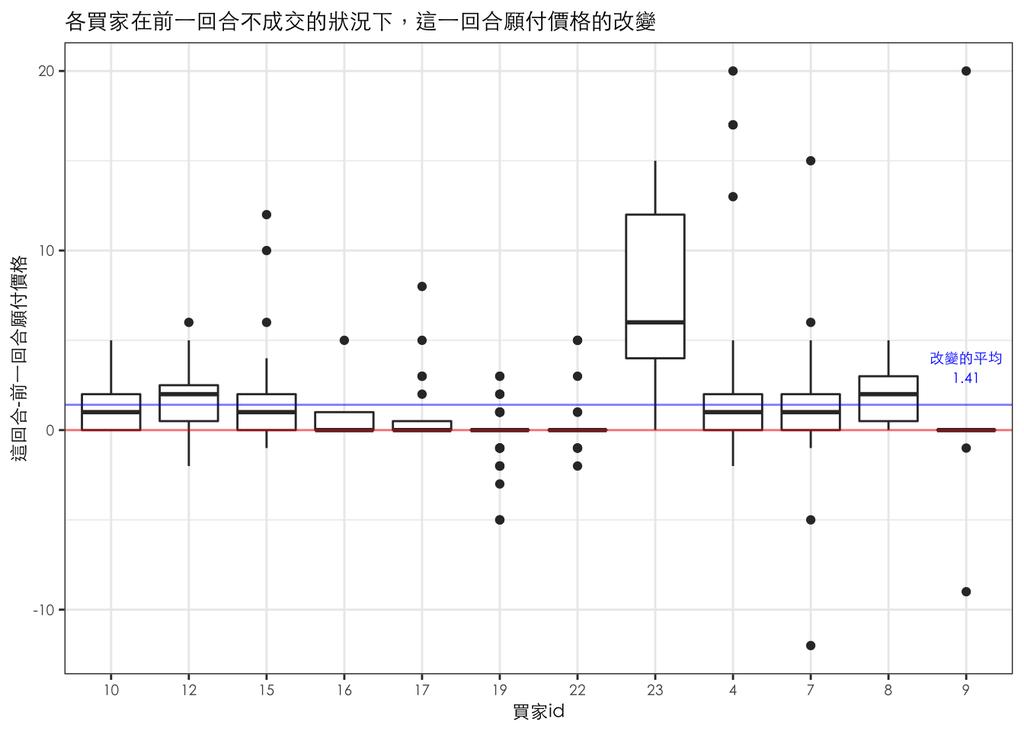

```r
deal <- function(ID=buyer_id, buyer=1, accept=1){
  list <- ""
  id <- ""
  for (i in ID) {
    for (j in 1:50) { # period
      row <- filter(data, period == j & subject == i)
      if (j != 50) {
        next_period <- filter(data, period == j+1 & subject == i)
        if (row$accept == accept) { # reject/ accept
          if (buyer == 1){ # buyer
            list <- append(list, next_period$share - row$share)
            id <- append(id, i)
          }else{ # seller
            list <- append(list, (next_period$price-1/2*next_period$tv) - (row$price-1/2*row$tv))
            id <- append(id, i)
          }
        }
      }
    }
  }
  list_df <- data.frame(id = id, change = list, stringsAsFactors = FALSE)
  list_df <- list_df[-1,]
  list_df$change <- as.numeric(list_df$change)
  return(list_df)
}
##### 買家 前一回合交易失敗，這一回合願付價格的改變
buyer_reject <- deal(buyer_id, 1, 0)
ggplot() +
  geom_boxplot(buyer_reject, mapping = aes(x = id, y = change)) +
  geom_hline(aes(yintercept = mean(buyer_reject$change)), color = "blue", alpha = 0.5) +
  geom_hline(aes(yintercept = 0), color = "red", alpha = 0.5) +
  geom_text(aes(x = "9", y = 3.5, label = paste0("改變的平均\n",round(mean(buyer_reject$change),2)), family = "黑體-繁 細體"), size = 2.5, color = "blue") +
  labs(title = "各買家在前一回合不成交的狀況下，這一回合願付價格的改變", x = "買家id", y = "這回合-前一回合願付價格")+
  theme_bw() +
  theme(text=element_text(family = "黑體-繁 細體", size = 9))
```

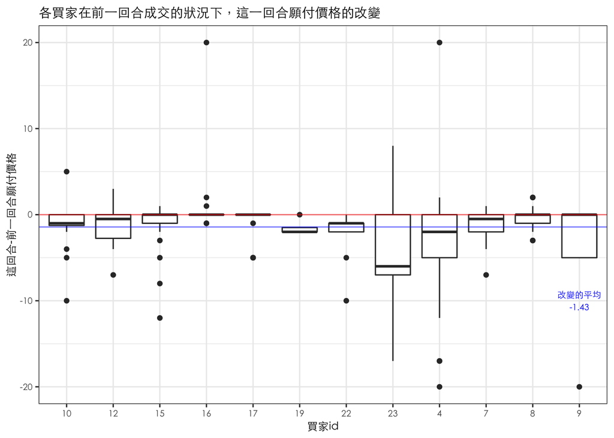

```r
##### 買家 前一回合交易成功，這一回合願付價格的改變
buyer_accept <- deal(buyer_id, 1, 1)
ggplot() +
  geom_boxplot(buyer_accept, mapping = aes(x = id, y = change)) +
  geom_hline(aes(yintercept = mean(buyer_accept$change)), color = "blue", alpha = 0.5) +
  geom_hline(aes(yintercept = 0), color = "red", alpha = 0.5) +
  geom_text(aes(x = "9", y = -10, label = "改變的平均\n-1.43", family = "黑體-繁 細體"), size = 2.5, color = "blue") +
  labs(title = "各買家在前一回合成交的狀況下，這一回合願付價格的改變", x = "買家id", y = "這回合-前一回合願付價格")+
  theme_bw() +
  theme(text=element_text(family = "黑體-繁 細體", size = 9))
```

```r
##### 買家 前一回合交易失敗/成功，這一回合願付價格的改變
buyer_change <- rbind(buyer_accept %>% mutate(accept = 1), buyer_reject %>% mutate(accept = 0))

buyer_model <- lm(data = buyer_change, change ~ accept)
summary(buyer_model)
```

```
#>
#> Call:
#> lm(formula = change ~ accept, data = buyer_change)
#>
#> Residuals:
#>      Min       1Q   Median       3Q      Max
#> -18.5700  -1.4097  -0.4097   1.4300  21.4300
#>
#> Coefficients:
#>             Estimate Std. Error t value Pr(>|t|)
#> (Intercept)   1.4097     0.2276   6.195  1.1e-09 ***
#> accept       -2.8397     0.3186  -8.914  < 2e-16 ***
#> ---
#> Signif. codes:  0 '***' 0.001 '**' 0.01 '*' 0.05 '.' 0.1 ' ' 1
#>
#> Residual standard error: 3.862 on 586 degrees of freedom
#> Multiple R-squared:  0.1194, Adjusted R-squared:  0.1179
#> F-statistic: 79.45 on 1 and 586 DF,  p-value: < 2.2e-16
```

### 問題 2：賣家的出價(price)受到什麼因素影響?

#### 假設一：前一次交易失敗/成功

統計上不顯著 p-value: 0.88

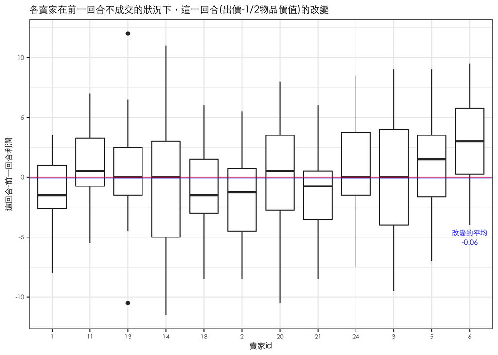

```r
##### 賣家 前一回合交易失敗，這一回合願付價格的改變
seller_reject <- deal(seller_id, 0, 0)
ggplot() +
  geom_boxplot(seller_reject, mapping = aes(x = id, y = change)) +
  geom_hline(aes(yintercept = mean(seller_reject$change)), color = "blue", alpha = 0.5) +
  geom_hline(aes(yintercept = 0), color = "red", alpha = 0.5) +
  geom_text(aes(x = "6", y = -5, label = paste0("改變的平均\n", round(mean(seller_reject$change),2)), family = "黑體-繁 細體"), size = 2.5, color = "blue") +
  labs(title = "各賣家在前一回合不成交的狀況下，這一回合(出價-1/2物品價值)的改變", x = "賣家id", y = "這回合-前一回合利潤")+
  theme_bw() +
  theme(text=element_text(family = "黑體-繁 細體", size = 8))
```

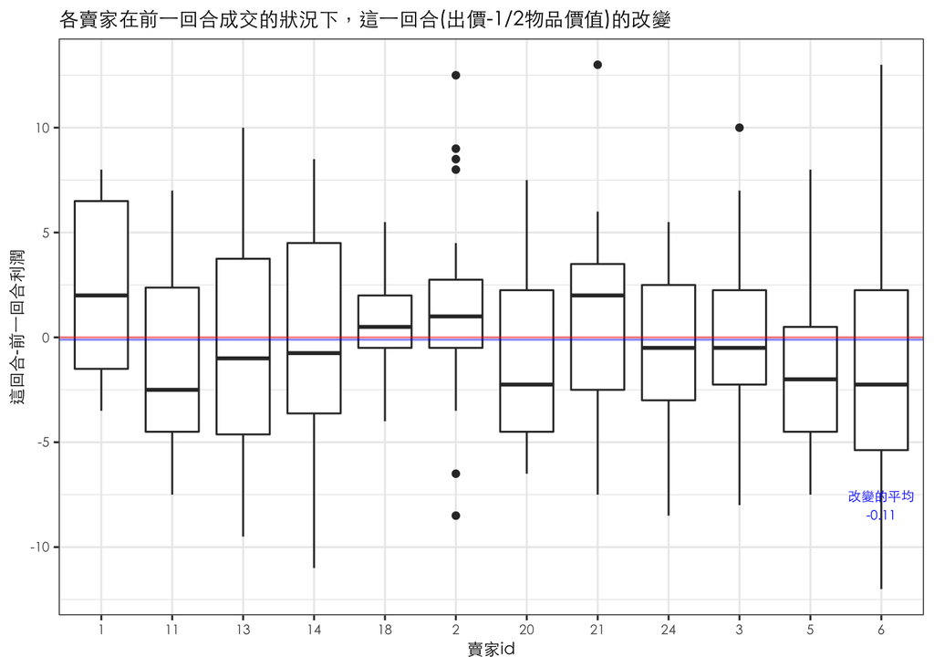

```r
##### 賣家 前一回合交易成功，這一回合願付價格的改變
seller_accept <- deal(seller_id, 0, 1)
ggplot() +
  geom_boxplot(seller_accept, mapping = aes(x = id, y = change)) +
  geom_hline(aes(yintercept = mean(seller_accept$change)), color = "blue", alpha = 0.5) +
  geom_hline(aes(yintercept = 0), color = "red", alpha = 0.5) +
  geom_text(aes(x = "6", y = -8, label = "改變的平均\n-0.11", family = "黑體-繁 細體"), size = 2.5, color = "blue") +
  labs(title = "各賣家在前一回合成交的狀況下，這一回合(出價-1/2物品價值)的改變", x = "賣家id", y = "這回合-前一回合利潤")+
  theme_bw() +
  theme(text=element_text(family = "黑體-繁 細體", size = 9))
```

```r
##### 賣家 前一回合交易失敗/成功，這一回合願付價格的改變
seller_change <- rbind(seller_accept %>% mutate(accept = 1), seller_reject %>% mutate(accept = 0))

seller_model <- lm(data = seller_change, change ~ accept)
summary(seller_model)
```

```
#>
#> Call:
#> lm(formula = change ~ accept, data = seller_change)
#>
#> Residuals:
#>     Min      1Q  Median      3Q     Max
#> -11.890  -2.944  -0.390   3.056  13.110
#>
#> Coefficients:
#>             Estimate Std. Error t value Pr(>|t|)
#> (Intercept) -0.05556    0.26330  -0.211    0.833
#> accept      -0.05444    0.36863  -0.148    0.883
#>
#> Residual standard error: 4.468 on 586 degrees of freedom
#> Multiple R-squared:  3.722e-05,  Adjusted R-squared:  -0.001669
#> F-statistic: 0.02181 on 1 and 586 DF,  p-value: 0.8826
```

#### 假設二：物品價值

統計上顯著 p-value: < 2.2e-16

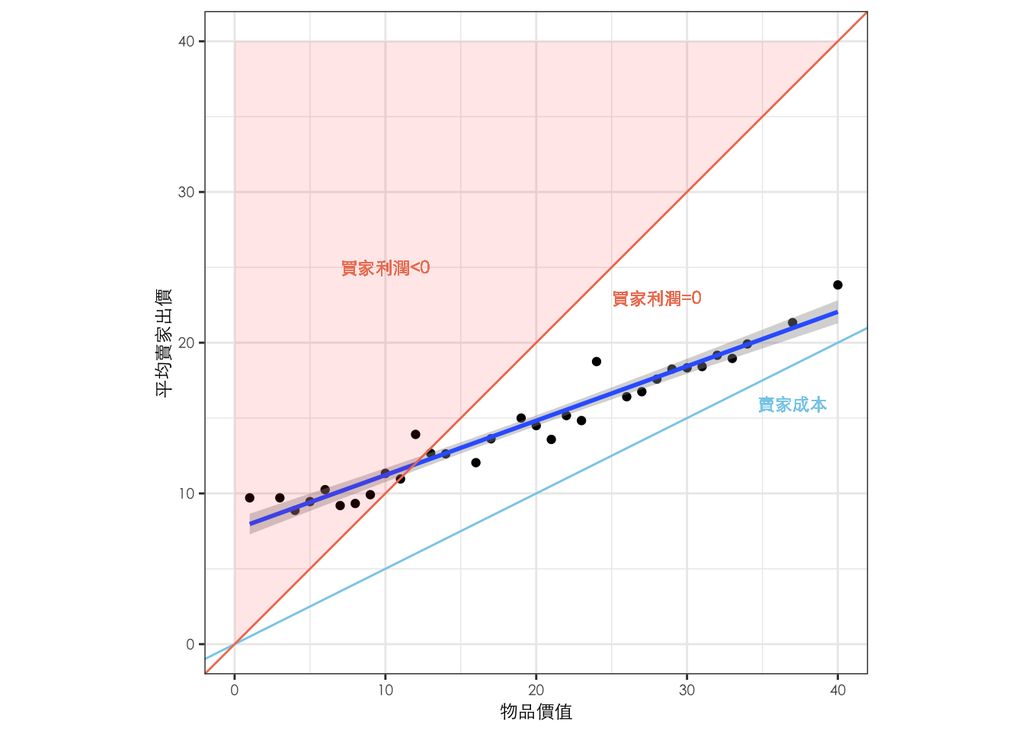

```
#>
#> Call:
#> lm(formula = mean_price ~ tv, data = seller_tv_p)
#>
#> Residuals:
#>     Min      1Q  Median      3Q     Max
#> -1.6062 -0.5851 -0.1131  0.3659  2.4772
#>
#> Coefficients:
#>             Estimate Std. Error t value Pr(>|t|)
#> (Intercept)  7.60730    0.35001   21.73   <2e-16 ***
#> tv           0.36106    0.01592   22.69   <2e-16 ***
#> ---
#> Signif. codes:  0 '***' 0.001 '**' 0.01 '*' 0.05 '.' 0.1 ' ' 1
#>
#> Residual standard error: 0.9774 on 30 degrees of freedom
#> Multiple R-squared:  0.9449, Adjusted R-squared:  0.9431
#> F-statistic: 514.6 on 1 and 30 DF,  p-value: < 2.2e-16
```

```r
# 物品質＆平均賣家出價
seller_tv_p <- seller_data %>%
  group_by(tv) %>%
  summarise(mean_price = mean(price))

tvLM <- lm(mean_price ~ tv, data = seller_tv_p)
summary(tvLM)
tri <- data.frame(x = c(0,0,40), y = c(0,40,40))

ggplot(seller_tv_p) +
  geom_point(aes(x = tv, y = mean_price)) +
  theme_bw() +
  geom_smooth(method = lm, aes(x = tv, y = mean_price)) +
  ylim(0,40) +
  theme(aspect.ratio=1) +
  geom_abline(intercept = 0, slope = 1/2, color = "skyblue") +
  geom_abline(intercept = 0, slope = 1, color = "salmon2") +
  geom_polygon(mapping = aes(x=x, y=y), data=tri, alpha=0.1, fill="red")+
  labs(x = "物品價值", y = "平均賣家出價") +
  geom_text(aes(x = 10, y = 25, label = "買家利潤<0", family = "黑體-繁 細體"), size = 3, color = "salmon2") +
  geom_text(aes(x = 28, y = 23, label = "買家利潤=0", family = "黑體-繁 細體"), size = 3, color = "salmon2") +
  geom_text(aes(x = 37, y = 16, label = "賣家成本", family = "黑體-繁 細體"), size = 3, color = "skyblue") +
  theme(text=element_text(family = "黑體-繁 細體", size = 9))
```

### 買家高報酬策略範例—16號玩家

- 買家平均總利潤：28.6
- 16號玩家總利潤：135

推測16號玩家（買家）於一開始為了建立「買家不是好欺負的」名聲，讓賣家不敢隨意出價以剝削買家。舉例來說，若買家願付價格一直或是有很大的機率很高，賣家因為認為成交的機率很高，可能就不管物品價值的高低一律開出高價以剝削買家。

35回合以後，16號玩家改變策略，最後的15回合願付價格皆為40（最高），此時他的各局報酬有正有負，但由於其餘大部分的買家願付價格都較低，賣家害怕無法成交平均來說不會將價格訂太高，16號玩家的平均報酬仍 > 0。

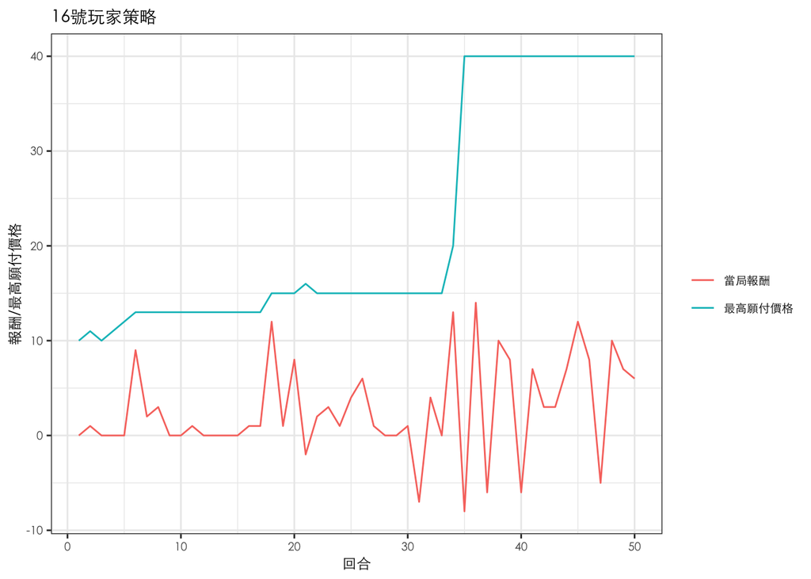

```r
# player_16
player_16 <- buyer_data %>%
  filter(subject == "16") %>%
  select(period, share, profit) %>%
  gather(cat, value, share, profit)

ggplot(player_16) +
  geom_line(aes(x = period , y = value, color = cat)) +
  labs(x = "回合", y = "報酬/最高願付價格", title = "16號玩家策略") +
  theme_bw() +
  theme(text=element_text(family = "黑體-繁 細體", size = 9)) +
  scale_colour_discrete(name = "", breaks=c("profit", "share"),
                        labels=c("當局報酬", "最高願付價格"))
```